# MCP Console · R, Python, and SQL together

## MCP Console

Why Console exists

R, Python, and SQL.  
One execution system.

A shared workbench for the AI systems we build.

## Equip the model with R, Python, and SQL

Languages available to the model

**R**

Statistical methods, analysis packages, and data visualization.

**Python**

Machine learning libraries and the broader Python ecosystem.

**SQL**

Local or remote database connections. Optimized queries.

The model can choose the language and syntax it works best with.

## Full capabilities and full safety

One execution system we can reuse

**Use full runtimes**

Libraries and native code.  
Subprocesses and forks.  
Text and plots.

**Drive a real session**

Persistent objects.  
Input, waits, and controls.  
Explicit runtime state.

**Enforce permissions**

Filesystem and network policy.  
Subprocesses covered.  
Shutdown and cleanup.

Managed packages, bounded output, session records, and local or remote execution.

## Connect Console to your agent harness

Where the calls come from

**MCP clients**

Compatible MCP stdio clients, including Codex and Claude Code.

**R harnesses**

ellmer through mcp.console.

**Python harnesses**

Sync and async clients.  
chatlas.  
OpenAI Responses and Agents SDK.  
Anthropic.  
Codex thread SDK.

## Send a cell of code

The common case · one simple call

LLM client → Console

```python
console.send(r="""
  d <- read.csv("examples/measurements.csv")
  fit <- lm(response ~ temperature + group,
            data = d)
  fit
""")
```

R output

```
Call:
lm(formula = response ~ temperature + group, data = d)

Coefficients:
(Intercept)  temperature       groupB
      6.889        1.007        1.273
```

Define objects, see printed output, and continue in the same session.

## Return plots

Evaluate code and see the result

LLM client → Console

```python
console.send(r="""
  plot(d$temperature, d$response,
       xlab = "Temperature",
       ylab = "Response")
""")
```

R graphics output

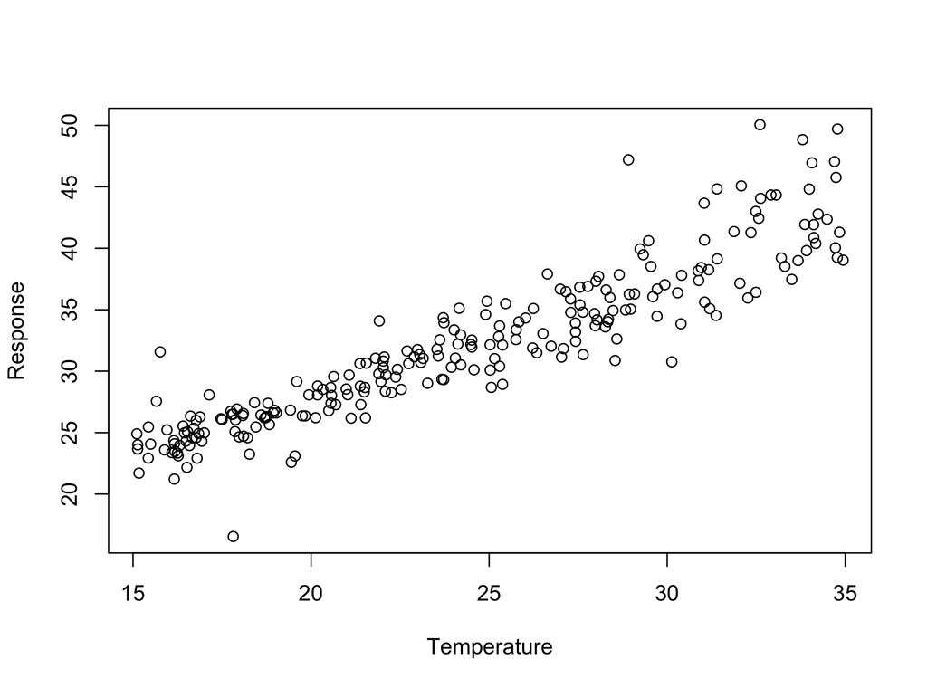

R graphics return an image.

## Python uses the same call

Send a Python cell

Python cell

```python
console.send(python="""
values = [2, 3, 5, 7]
print(sum(values))
""")
```

Console response

```
17
```

Supply `python=` to evaluate a Python cell.

## Python plots return images too

Evaluate code and see the result

Python cell

```python
console.send(python="""
import matplotlib.pyplot as plt

plt.plot(values, marker="o")
plt.xlabel("Index")
plt.ylabel("Value")
""")
```

Matplotlib output

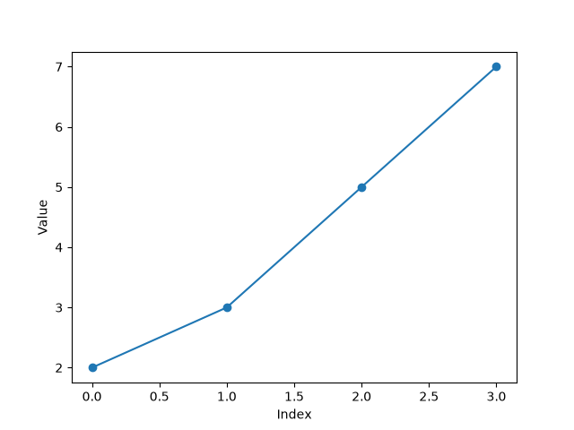

The response carries the image produced by the cell.

## R and Python share the same process

Use objects from either language

Python reads the R data frame

```python
console.send(python='len(r.d)')
```

Console response

```
240
```

R reads the Python list

```python
console.send(r='length(py$values)')
```

Console response

```
[1] 4
```

`r.d` exposes the R object to Python. `py$values` exposes the Python object to R.

## Query the same data with SQL

SQL in the same session

SQL cell

```python
console.send(sql="""
SELECT "group", COUNT(*) AS n
FROM d
GROUP BY "group"
ORDER BY "group"
""")
```

Captured result

```
# A tibble: 2 × 2
  group          n
  <string> <int64>
1 "A"          120
2 "B"          120
```

## SQL uses the connection you choose

One analysis · choose the database connection in R or Python

R · a DBI connection

```python
console.send(r="""
  con <- DBI::dbConnect(
    RSQLite::SQLite(), ":memory:")
  console_sql_connection(con)
""")
```

Python · a DB-API connection

```python
console.send(python="""
import sqlite3
con = sqlite3.connect(":memory:")
console_sql_connection(con)
""")
```

Subsequent SQL cells use the selected connection

```python
console.send(sql="SELECT CURRENT_TIMESTAMP AS now")
```

Use a local database or an existing remote connection through its driver.

## Make CRAN and PyPI available to the session

Use the package ecosystem

A model may avoid a useful package to avoid changing the user’s environment.

**Let the task choose the library**

The model can use a trusted package when the analysis calls for it.

**Manage the environment for the session**

Console retains requirements and prepares compatible package environments.

Ordinary package use can request the dependency it needs.

## Use the package; let the runtime prepare it

Use the package ecosystem

R

```python
console.send(r="library(data.table)")
```

Python

```python
console.send(python="import polars")
```

Reach a missing package → resolve → activate → continue

The live workspace stays available during supported additions.

## Separate session control from code execution

How the processes fit together · local execution

[figure not shown]

The server manages the session. The worker executes code inside the sandbox.

## Declare package requirements explicitly

Use the package ecosystem

Prepare dependencies

```python
console.send(
  requirements={
    "r": ["dtplyr"],
    "python": ["scikit-learn==1.9.1"],
  },
)
```

Name a package without a version.

Pin a specific version when needed.

Prepare it before evaluating code.

Requirements can also accompany a code cell in the same call.

## Use a Python library on the same data

One analysis · R and Python together

LLM client → Console · Python cell

```python
console.send(python="""
from sklearn.ensemble import RandomForestRegressor
from sklearn.model_selection import cross_val_score
import pandas as pd

frame = r.d
X = pd.get_dummies(frame[["temperature", "group"]])
model = RandomForestRegressor(random_state=42)
scores = cross_val_score(model, X, frame["response"],
                         cv=5, scoring="neg_mean_absolute_error")
print(f"CV MAE: {-scores.mean():.3f}")
""")
```

Captured Python result

```
[resolved PyPI distribution 'scikit-learn' for Python import 'sklearn']
CV MAE: 2.015
```

## Collect progress while the code keeps running

Detail 1 · Waiting preserves the computation

LLM client → Console · running cell

```python
console.send(r="""
  pb <- txtProgressBar(
    max = 20, style = 3, width = 20)
  for (i in 1:20) {
    Sys.sleep(0.15)
    setTxtProgressBar(pb, i)
  }
  close(pb)
""", timeout_ms=450)
```

Console → text · captured response

```
[running; poll with an empty send]
```

## Pick up the next output from the same run

Detail 1 · Waiting and readable progress

LLM client → Console · collect new output

```python
console.send(timeout_ms=600)

console.send(timeout_ms=5000)
```

Console → text · after 600 ms

```
[running; poll with an empty send]
```

## Protect the model’s context from oversized output

Detail 2 · Bound the response and retain the full output

Call

```python
console.send(r=r"""
  for (i in seq_len(10000)) {
    cat(sprintf("row %05d\n", i))
  }
  cat("fit complete\n")
""")
```

One tool response · shortened for display

```
row 00001
row 00002
row 00003

[output preview: middle omitted;
 raw output retained at
 .agents/console/sessions/<run>/
 outputs/call-000008.log]

row 09999
row 10000
fit complete
```

## Capture output below the language hooks

Detail 2 · Native output belongs in the result

R · forked child writes through a pipe

```python
console.send(r=r"""
  job <- parallel::mcparallel({
    out <- pipe("cat", "w")
    cat("hello from fork\n", file = out)
    close(out)
  })
  invisible(parallel::mccollect(job))
""")
```

Console response

```
hello from fork
```

Python · write directly to stdout

```python
console.send(python=r"""
import os
os.write(1, b"hello directly on fd 1\n")
""")
```

Console response

```
hello directly on fd 1
23
```

Capture native output from the worker and its children.

## Interrupt or restart the session

Work with the session

Interrupt

```python
console.send(control="interrupt")
```

Interrupt a long-running computation. Keep the workspace.

Restart

```python
console.send(control="restart")
```

Replace the worker. Start with fresh in-memory state.

Combine a control and a code cell in one call.

R package development

```python
# Run the package tests in a fresh session
console.send(control="restart", r="devtools::test()")

# Load the package, then evaluate more code
console.send(control="restart", r="devtools::load_all(); ...")
```

Restart keeps prepared dependencies and starts the supplied cell in the new session.

## Send input to an R prompt

Work with the session

Run code that asks for input

```python
console.send(r="""
  name <- readline("name> ")
  name
""")
```

Response · waiting for input

```
[input requested: "name> "]
[waiting for stdin]
```

Supply a line of standard input

```python
console.send(stdin='Ada\n')
```

Response · the same cell resumes

```
[1] "Ada"
```

Send the answer through `stdin`, including the newline.

## Send input to a paused debugger

Work with the session

Pause inside an R function

```python
console.send(r="""
  inspect_mean <- function(x) {
    browser()
    mean(x)
  }

  inspect_mean(c(1, 2, 3))
""")
```

Response

```
Called from: inspect_mean(c(1, 2, 3))
[input requested: "Browse[1]> "]
[waiting for stdin]
```

Inspect x

```python
console.send(stdin='x\n')
```

Response

```
[1] 1 2 3
[input requested: "Browse[1]> "]
[waiting for stdin]
```

Continue

```python
console.send(stdin='c\n')
```

Response

```
[1] 2
```

## Run an interactive script in a fresh session

Work with the session

./summarize.R

```r
group <- readline("Group to summarize: ")
d <- readr::read_csv("./measurements.csv",
                     show_col_types = FALSE)
values <- d$response[d$group == group]
print(summary(values))
```

Four arguments · one send call

```python
console.send(
  control="restart",
  requirements={"r": ["readr"]},
  stdin="A\n",
  r='source("./summarize.R")'
)
```

One response · captured from Console

```
[worker stopped: in-memory state lost]
[starting new worker]
[input requested: "Group to summarize: "]
   Min. 1st Qu.  Median    Mean 3rd Qu.    Max.
  16.55   26.50   31.29   31.60   35.47   45.76
[done]
```

Prepare readr → restart → queue input → source the script.

## The current send() interface

The model-facing API today

```
console.send(
  r=…, python=…, sql=…,    # at most one language
  control=…,               # interrupt or restart
  stdin=…,                 # input for a read or prompt
  requirements={r: …, python: …, duckdb: …},
  timeout_ms=…,            # how long this call waits
)
```

Omit code to poll, supply input, control the session, or prepare dependencies.

## Possible extension: multiple sessions

API ideas · not implemented

```
console.send(
  r=…, python=…, sql=…,    # at most one language
  session=…,               # which session to address
  control=…,               # interrupt or restart
  stdin=…,                 # input for a read or prompt
  requirements={r: …, python: …, duckdb: …},
  timeout_ms=…,            # how long this call waits
)
```

Let the model manage several sessions and keep work running concurrently.

## Possible extension: a session notebook

API ideas · not implemented

```
console.send(
  r=…, python=…, sql=…,    # at most one language
  session=…,               # which session to address
  note=…,                  # append prose to the record
  control=…,               # interrupt or restart
  stdin=…,                 # input for a read or prompt
  requirements={r: …, python: …, duckdb: …},
  timeout_ms=…,            # how long this call waits
)
```

`note` is a working name; it could also be `comment`.

Append intentions, observations, and conclusions alongside the code and results.

## Default policy: read-only

Choose the worker’s permissions

- Read all host files your account can access.
- Write only in private temporary storage.
- Restrict direct network access.
- Apply the same policy to subprocesses.
- On restart or shutdown, stop the worker and children; remove temporary storage.

Host reads are allowed. Deny sensitive paths explicitly.

## Choose between two built-in sandbox policies

Choose the worker’s permissions

### :read-only

- Read host files.
- Write only in private temporary storage.
- Project files stay protected from writes.

```bash
mcp-console serve \
  -c extends=:read-only
```

### :workspace

Adds writes in the **workspace**: the directory where you launch Console.

Write access stays denied for `.git`, `.agents`, `.codex`, and `.claude`. These subdirectories remain readable.

```bash
mcp-console serve \
  -c extends=:workspace
```

Both restrict networking and provide private storage and process cleanup.

## Extend a built-in policy for the project

Choose the worker’s permissions

./data: read-only.

./secrets and ./.env: reads and writes denied.

Other workspace paths: writable, with protected project metadata.

.agents/console/config.yaml

```yaml
extends: ":workspace"
sandbox:
  filesystem:
    entries:
      - path: {type: path, path: ./data}
        access: read
      - path: {type: path, path: ./secrets}
        access: deny
      - path: {type: path, path: ./.env}
        access: deny
```

Set project permissions in .agents/console/config.yaml.

## Example: connect to a corporate data warehouse

Choose the worker’s permissions

Route worker traffic through the managed proxy.

Allow the corporate warehouse host.

Use its HTTPS database API, or a SOCKS-aware database connection.

.agents/console/config.yaml · excerpt

```yaml
sandbox:
  proxy:
    enabled: true
    domains:
      warehouse.example.com: allow
```

The client still supplies its usual database credentials.

## Example: develop a local Shiny app

Choose the worker’s permissions

allowLocalBinding: true

Run Shiny on the loopback interface.

Open `http://127.0.0.1:8000` in your browser.

.agents/console/config.yaml · excerpt

```yaml
sandbox:
  proxy:
    enabled: true
    allowLocalBinding: true
```

`shiny::runApp("app", host = "127.0.0.1", port = 8000)`

## The complete proxy configuration

Choose the worker’s permissions

Enable the proxy explicitly.

Set allowed destinations in `domains`.

Opt into local binding for Shiny.

Keep UDP, upstream proxies, and broad Unix-socket access off unless needed.

Empty rule maps grant no destinations. The default policy has no proxy.

.agents/console/config.yaml

```yaml
extends: ":workspace"
sandbox:
  network: restricted
  proxy:
    enabled: true
    enableSocks5: true
    enableSocks5Udp: false
    allowUpstreamProxy: false
    dangerouslyAllowAllUnixSockets: false
    allowLocalBinding: false
    mode: full
    domains: {}
    unixSockets: {}
```

## Run any command through the sandbox

Reuse the sandbox in your own application

Public command-line interface

```bash
mcp-console sandbox -- Rscript examples/sandbox-analysis.R
```

**Choose the policy**

Use the same project config and command-line overrides.

**Run the command**

Console hands execution to the native sandbox runner. Its restrictions apply to the command and its children.

**Connect your application**

Use ordinary stdin, stdout, stderr, and exit status.

Reuse the sandbox from your own tools and agent harnesses.

## Configure where the session runs

Choose the execution host

**Local host**

Beside your project, using this machine’s files and compute.

**SSH host**

On an existing remote machine, beside its data and compute.

**Docker container**

Inside a prepared image, with the mounts you select.

Execution targets plug into the same session interface.

## Move execution to the remote host

The same architecture over SSH

[figure not shown]

Code runs beside the remote data. The client and session records stay local.

## Send code to the remote host; receive results

SSH · Keep computation beside the existing data

**Your machine**

MCP client and Console server.

Send cells and controls.  
Receive text and plots.  
Keep session records.

**Remote host**

Sandboxed session worker.

Use the files already there.  
Run R, Python, and SQL.  
Prepare packages there.

The source data stays on the remote host. Results return over SSH.

## Point Console at the remote workspace

SSH · Use an existing analysis host

Remote workspace and relative paths.

Remote runner and resolver.

Local MCP server and recordings.

.agents/console/config.yaml

```yaml
extends: ":workspace"
target:
  transport:
    kind: ssh
    host: analysis-host
  workspace: /srv/projects/analysis
sandbox:
  filesystem:
    entries:
      - path: {type: path, path: ./data}
        access: read
```

## Build the session’s Docker image at launch

Docker · Choose the session environment

Start with Rocker. Add uv, rig, and ir.

examples/Dockerfile

```
FROM rocker/tidyverse
ENV UV_INSTALL_DIR=/usr/local/bin
ENV UV_TOOL_BIN_DIR=/usr/local/bin
ENV RIG_PREFIX=/usr/local
RUN curl -LsSf https://astral.sh/uv/install.sh | sh
RUN curl -LsSf https://r-lib.github.io/rig/install.sh | sh
RUN uv tool install r-lib-ir
WORKDIR /workspace
```

.agents/console/config.yaml

```yaml
target:
  workspace: /workspace
  command: [uvx, mcp-console]
  compute:
    kind: docker
    build:
      context: .
      dockerfile: ./examples/Dockerfile
    mounts:
      - source: .
        target: /workspace
        access: read_write
sandbox:
  filesystem: {kind: external-sandbox}
  network: enabled
```

## The agent uses the same interface on every host

Local · SSH · Docker

send

```python
console.send(r="coef(fit)")
```

Local host / SSH / Docker

## Launch or install Console

Installation

Recommended · launch an MCP server

```bash
uv tool install mcp-console
```

```bash
uvx mcp-console
```

Persistent Python installation · choose the integrations you need

```bash
uv pip install "mcp-console[client,chatlas,openai,openai-agents,anthropic,codex]"
```

R package · planned CRAN installation

```r
install.packages("mcp.console")
```

Let `uvx` manage resolution and automatically pick up updates.

## Register Console with your CLI client

Use the client you already work in

Codex CLI

```bash
codex mcp add console -- uvx mcp-console serve
```

Claude Code CLI

```bash
claude mcp add console -- uvx mcp-console serve
```

Register the launch command; your client starts Console.

## ellmer

Use the client you already work in

R · register one tool

```r
library(ellmer)
library(mcp.console)

chat <- chat_openai()
chat$register_tool(console_tool())
chat$chat("Analyze measurements.csv with Console.")
```

Your chat and provider. A separate persistent Console worker.

## chatlas

Use the client you already work in

Python · register one tool

```python
from chatlas import ChatOpenAI
import mcp_console

chat = ChatOpenAI()
with mcp_console.MCPConsole() as console:
    chat.register_tool(mcp_console.chatlas.tool(console))
    chat.chat("Analyze measurements.csv with Console.")
```

The same registration pattern in Python.

## Keep session logs and readable transcripts

Keep the work useful after the session

Files under one session directory

```
.agents/console/sessions/<session-id>/
├── internal/
│   └── events.jsonl     # Calls, results, request metadata
├── outputs/
│   └── call-000003.log  # Raw cell output
├── artifacts/
│   └── *.png           # Captured plots
├── transcript.md       # Readable session history
└── transcript.qmd      # Executable code cells
```

Full logs and a readable presentation of the session.

## Read the session as Markdown

Keep the work useful after the session

transcript.md · recorded call and result

````markdown
## Call 4: R

```r
coef(fit)
```

## Result for call 4

```text
(Intercept) temperature      groupB
   6.888528    1.007196    1.273078
```
````

Code and captured results stay together in the session history.

## Turn the session into an editable starting point

Keep the work useful after the session

report.qmd · edited copy of the session transcript

````markdown
---
title: MCP Console code cells
knitr:
  opts_knit:
    root.dir: <project>
ir:
  exclude-newer: "2026-09-17"
  isolated: true
  packages: [tidyverse, reticulate]
---

```{r}
  d <- read.csv("examples/measurements.csv")
  fit <- lm(response ~ temperature + group,
            data = d)
  fit
```
````

`ir render report.qmd` uses the recorded package snapshot date.

## Before an official release

Pending work

- **Windows support:** mostly stubbed out; open PRs still need to land.
- **Sans-R mode:** running without R; in flight.
- **Human-facing configuration:** readable YAML, discovery, and storage defaults.
- **Tool descriptions and evals:** convey capabilities clearly and use fewer tokens.
- **Curated session exports:** Quarto documents and timestamped lab notebooks.
- **Artifact handoff:** persistent output locations for other authorized tools.

The agent-facing API is largely complete. The human-facing experience needs another pass.

## R, Python, and SQL, available for the work

Why Console exists

Let the model choose the language.  
You choose the execution host.  
Give the agent an interactive workbench.

Full language capabilities, with a sandbox that enforces the access you allow.

## Appendix

Backup material

Configuration, project history, and development practices.

How the capabilities evolved, and how their behavior is checked.

## Example: use approved package repositories

Appendix · package sources

Use a corporate mirror or a Posit Package Manager repository.

A curated repository exposes an approved set of packages and versions.

Restrict the resolver host’s network access to enforce approved sources.

MCP client launch settings · YAML view

```yaml
mcpServers:
  console:
    command: uvx
    args: [mcp-console, serve]
    env:
      PKG_CRAN_MIRROR: >-
        https://ppm.example.com/r/latest
      UV_DEFAULT_INDEX: >-
        https://ppm.example.com/python/simple
```

Choose which packages are available for resolution.

## Proposed: declare requirements in config.yaml

Appendix · session requirements

Prepare dependencies through send()

```python
console.send(
  requirements={
    "r": ["dtplyr"],
    "python": ["scikit-learn==1.9.1"],
  },
)
```

.agents/console/config.yaml · proposed

```yaml
requirements:
  r:
    - dtplyr
  python:
    - scikit-learn==1.9.1
```

Config form is not implemented yet.

Name packages or pin versions for the session.

## Follow a package-resolution request

Private worker protocol · illustrative paths

1. R reaches a missing package and the worker requests resolution.
2. The server prepares a library with `ir`, outside the worker sandbox.
3. The worker activates the library and continues the original load.

Worker → server

```json
{"kind": "resolve_r",
 "packages": ["data.table"]}
```

Server → worker

```json
{"kind": "r_resolved",
 "library": "/cache/r/library"}
```

Worker → server

```json
{"kind": "r_activated",
 "library": "/cache/r/library"}
```

Trusted preparation can use the network while the worker remains restricted.

## Capabilities arriving on main

Appendix · repository development · July–September 2026

[figure not shown]

279 PRs merged directly into main · July 27–September 18 · height is lines added + deleted.

Language support came first; package management and execution targets followed.

## How much is in the repository?

Appendix · repository development · absolute size

[figure not shown]

Complete file contents at 307 commits on main · includes comments, blank lines, tests, docs, and tooling.

143,123 tracked text lines by September 18, including the test suite and its evidence.

## What grew alongside the core code?

Appendix · repository development · contents by category

[figure not shown]

Same total, split by file category · YAML test transcripts are tracked across directory reorganizations.

About 32k lines of core code, 60k of test code and fixtures, and 34k of test transcripts.

## How the proportions changed

Appendix · repository development · share of repository contents

[figure not shown]

Each date sums to 100% of tracked text lines · legend values are the September 18 shares.

Test code and transcripts grow to about 65% of the repository’s text.

## Why some PRs look so large

Appendix · repository development · review volume

[figure not shown]

Six largest PRs merged directly into main · lines added + deleted · same category colors as the repository charts.

The largest PR reorganized tests: 37,183 lines changed, but only 1,705 net lines added.

## AGENTS.md gives the model project context

Appendix · development practices · instructions in the repository

A Markdown file of project instructions that a coding agent reads before making changes.

**Where to look**

Architecture and module owners. Public interfaces. Development and validation commands.

**What to preserve**

Observable behavior. Readable errors and transcripts. Clear process and sandbox boundaries.

**How to change it**

A focused PR. A public regression test. Deterministic checks. Review of generated evidence.

The instructions connect a requested change to the project’s contracts and checks.

## The development loop starts with behavior

Appendix · development practices · the prescribed workflow

**1 · Describe**

Choose one observable behavior and the public interface that exercises it.

**2 · Reproduce**

Add a public test and see it fail before changing the implementation.

**3 · Implement**

Make the change, rerun the test, and inspect any updated transcripts.

**4 · Validate**

Format and run the full checks. Require CI and review on the current PR revision.

The test suite gives the agent and the reviewer a shared description of expected behavior.

## Rust implementation. Python integration tests.

Appendix · Development practices

Implement in Rust

Exercise from Python

## Test the boundaries you intend to preserve

Appendix · Development practices

[figure not shown]

One primary owner per behavior; lower layers test their own contracts.

## YAML is what the reviewer reads

Appendix · Development practices

Checked-in YAML · request

```yaml
send:
  r: |
    cores <- parallel::detectCores()
    stopifnot(
      length(cores) == 1L,
      !is.na(cores),
      cores >= 1L
    )
    writeLines("R core detection available")
```

Checked-in YAML · result

```yaml
result:
  content:
    - type: text
      text: |
        R core detection available
  isError: false
```

Readable code, arguments, output, and errors. Not escaped JSON strings.

Source excerpt: `detects_cpu_cores.yaml` · initialization document omitted.

## Normalize noise, not behavior

Appendix · Development practices

Unstable details

```
/tmp/run-8fd31/work.csv
worker pid: 27186
[waiting for stdin]
```

Schematic normalization

```
<WORKSPACE>/work.csv
worker pid: <PID>
[waiting for stdin]
```

Keep meaningful wording, ordering, and failure distinctions visible.

## Synchronize; do not sleep and hope

Appendix · Development practices

Start → checkpoint → release → assert

Explicit gates for output, cancellation, restart, and cleanup.

## Portable behavior; real capability checks

Appendix · Development practices

Shared cases  
direct + sandboxed

Capability fixtures  
SSH · Docker · SBX

Fake peers establish protocol contracts; real targets establish target behavior.

## Snapshots are generated evidence

Appendix · Development practices

Run, regenerate, review

```bash
scripts/test --update BOUNDARY/SUITE::CASE

git diff -- tests/snapshots/
```

## Test the installed product

Appendix · Development practices

Source build  
and wheels

R / Python clients  
and native bundle

Packaging, launch, schemas, images, shutdown, and cleanup are part of the contract.